# Trabalho Prático 1 - Ambientação

- **Nome:** Matheus Freitas Martins
- **Matrícula:** ES111281

O propósito deste trabalho é aprofundar o conhecimento em plataformas relevantes para análise e processamento de dados. Para alcançar esse objetivo, será configurada uma instância de máquina virtual na Azure, na qual serão instaladas as dependências requeridas para participar de uma competição de aprendizado de máquina no Kaggle.

Nesta competição, o desafio é desenvolver um modelo capaz de prever se um passageiro da Spaceship Titanic foi transportado para uma dimensão alternativa ou não, usando informações pessoais do passageiro. O resultado esperado é a criação de um modelo que possa classificar corretamente os passageiros em duas categorias: aqueles que foram transportados para outra dimensão e aqueles que não foram.

# Configurando o Ambiente

## Criando a máquina virtual

Conforme sugerido pela documentação, foi utilizado a plataforma Azure para criar a máquina virtual https://portal.azure.com/#home

Caminho: *Virtuais > Criar > Máquina Virtual do Azure*

Inicialmente, as seguintes configurações foram escolhidas para a máquina:

- Nome: **CCF726**
- Região: **(US) East US**
- Imagem (S.O): **Ubuntu Server 20.04 LTS - X64 Gen2**

[figure not shown]

Em relação a conta de administrador, foi escolhido autenticar-se por meio de uma senha.

- **Login**: mtsftsmts

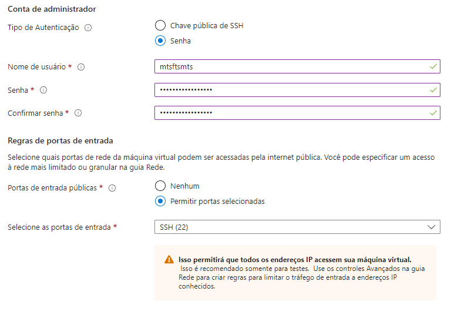

Uma vez definido essas pequenas configurações, prosseguiu-se clicando no botão "**Revisar + Criar**".

## Incluindo regra de inbound

Além das configurações básicas definidas anteriormente, é necessário incluir uma regra de inbound que vai habilitar acessar o Jupyter Notebook. Para isso, foi escolhido a porta **8888** e protocolo **TCP**.

**Caminho**: *Configurações > Rede > Adicionar regra da porta de entrada*

[figure not shown]

## Configurando IP estático

Além disso, para facilitar as futuras conexões foi atribuído a rede um ip estático.

**Caminho**: *Configurações > Configurações de IP*

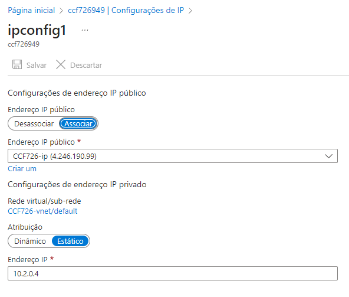

## Configurando dependências para a máquina virtual criada

Uma vez configurada, é necessário iniciar a máquina no Azure, clicando em "**Iniciar**".

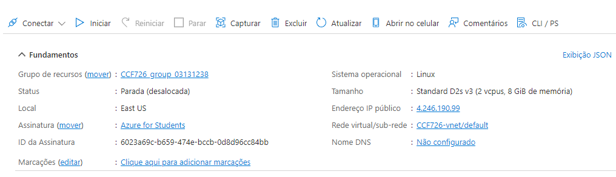

Abrir o programa Putty e inserir no campo Host Name (or IP address) o Endereço IP público da máquina "**4.246.190.99**".

[figure not shown]

Ao clicar em "**Open**" um terminal será aberto solicitando as credenciais do login.

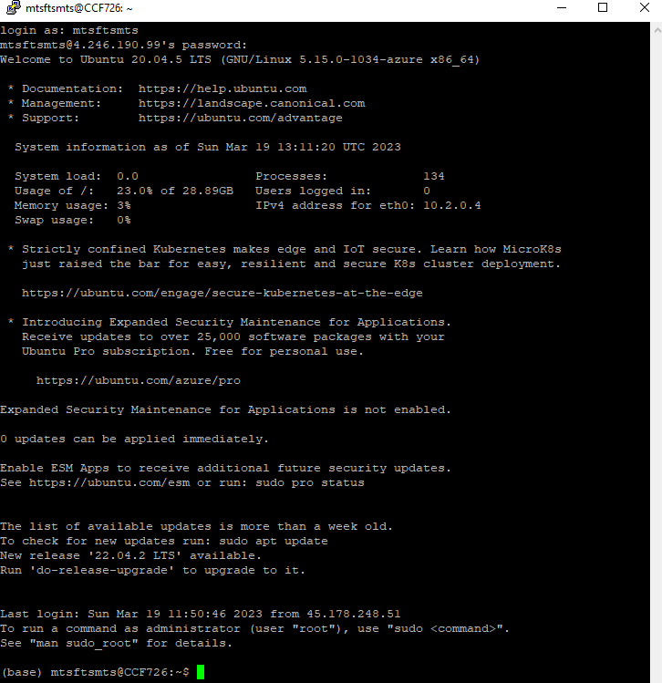

Em relação as dependências, foi escolhido instalar o pacote Anaconda, pois ele simplifica a instalação e o gerenciamento de pacotes, bibliotecas e ambientes para projetos de ciência de dados e aprendizado de máquina. Ele inclui um grande número de bibliotecas populares e úteis para esses campos, como Python, NumPy, pandas, Matplotlib, scikit-learn, TensorFlow, Jupyter Notebook, entre outras.

Após efetuar o login na máquina, os seguintes comandos foram executados:

- cd /tmp
- curl -O https://repo.anaconda.com/archive/Anaconda3-2022.10-Linux-x86_64.sh
- bash Anaconda3-2022.10-Linux-x86_64.sh
- Aceite os termos da licença

Após a instalação, execute o comando: **source ~/.bashrc**, para fazer as alterações no arquivo .bashrc e aplicar as novas configurações à sessão atual do terminal sem precisar fechar e abrir um novo terminal.

Uma vez instalado, é possível visualizar todas as bibliotecas instaladas pelo Anaconda através do comando: **conda list**.

OBS: A imagem abaixo mostra apenas algumas bibliotecas instaladas.

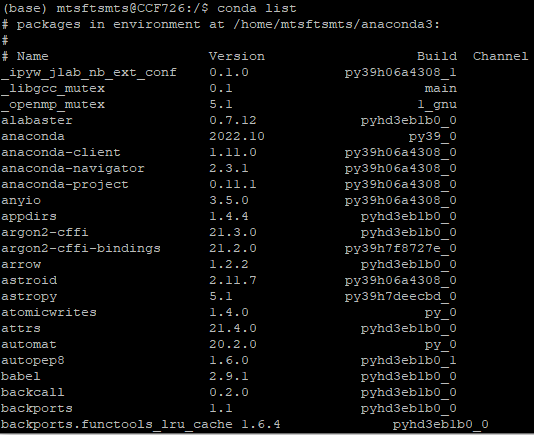

Podemos visualizar a versão dos pacotes de forma independente, abaixo podemos ver as versões do **Jupyter** e do **Python** instaladas.

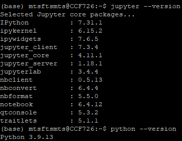

## Acessando o Jupyter da máquina virtual

Com a máquina virtual em execução, basta abrir o prompt do sistema operacional do computador pessoal e utilizar o seguinte comando para criar a instância para acessar o Jupyter remotamente:

### **ssh -L 8080:localhost:8888 mtsftsmts@4.246.190.99**

O comando: "`ssh -L 8080:localhost:8888 mtsftsmts@4.246.190.99`" realiza uma conexão SSH segura (Secure Shell) com a máquina remota cujo endereço IP é 4.246.190.99 e nome de usuário é mtsftsmts.

A opção -L 8080:localhost:8888 configura um túnel SSH, que encaminha o tráfego da porta local 8080 para a porta 8888 na máquina remota. Essa técnica é conhecida como "port forwarding" (encaminhamento de porta) e é útil quando deseja-se acessar um serviço na máquina remota (nesse caso, um servidor Jupyter Notebook na porta 8888) através de uma porta local do computador.

Com esse comando, é possível acessar o servidor Jupyter Notebook remoto digitando http://localhost:8080 no navegador do computador local, como se o servidor estivesse sendo executado localmente na porta 8080.

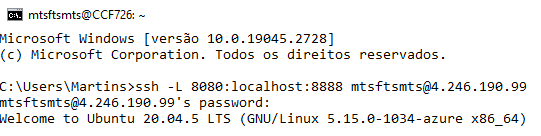

Em seguida, utilizar o seguinte comando: **jupyter notebook --no-browser**.

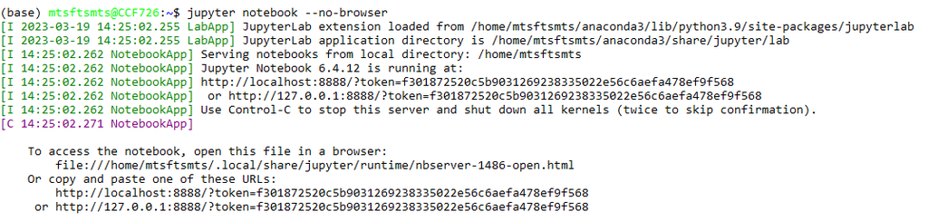

Agora, para acessar o Jupyter Notebook, basta digitar no navegador a seguinte URL: http://localhost:8080/tree?

Se necessário, insira o token gerado para obter acesso ao Jupyter. Por exemplo: http://localhost:8888/?token=1036cd4eb4546860f131cfb8a01c21423489643ae56efebd

Após acessar o Jupyter Notebook, você poderá criar um novo arquivo .ipynb e fazer upload de arquivos. Neste exemplo, foi criado o arquivo SpaceshipTitanic_TP1.ipynb e realizada a importação dos arquivos .csv de treinamento e teste, disponíveis em: https://www.kaggle.com/competitions/spaceship-titanic/data.

[figure not shown]

# Modelo utilizando Random Forest

## Importando bibliotecas

```python
import pandas as pd
from sklearn.ensemble import RandomForestClassifier
from sklearn.model_selection import train_test_split
from sklearn.metrics import accuracy_score
from sklearn.impute import SimpleImputer
```

## Carregando os dados

```python
dados_de_treino = pd.read_csv("train.csv")
dados_de_teste = pd.read_csv("test.csv")
```

## Entendendo os dados

Visualizando as cinco primeiras linhas do Dataframe.

```python
dados_de_treino.head()
```

|  | PassengerId | HomePlanet | CryoSleep | Cabin | Destination | Age | VIP | RoomService | FoodCourt | ShoppingMall | Spa | VRDeck | Name | Transported |
| --- | --- | --- | --- | --- | --- | --- | --- | --- | --- | --- | --- | --- | --- | --- |
| 0 | 0001_01 | Europa | False | B/0/P | TRAPPIST-1e | 39.0 | False | 0.0 | 0.0 | 0.0 | 0.0 | 0.0 | Maham Ofracculy | False |
| 1 | 0002_01 | Earth | False | F/0/S | TRAPPIST-1e | 24.0 | False | 109.0 | 9.0 | 25.0 | 549.0 | 44.0 | Juanna Vines | True |
| 2 | 0003_01 | Europa | False | A/0/S | TRAPPIST-1e | 58.0 | True | 43.0 | 3576.0 | 0.0 | 6715.0 | 49.0 | Altark Susent | False |
| 3 | 0003_02 | Europa | False | A/0/S | TRAPPIST-1e | 33.0 | False | 0.0 | 1283.0 | 371.0 | 3329.0 | 193.0 | Solam Susent | False |
| 4 | 0004_01 | Earth | False | F/1/S | TRAPPIST-1e | 16.0 | False | 303.0 | 70.0 | 151.0 | 565.0 | 2.0 | Willy Santantines | True |

Resumo geral da estrutura e conteúdo do Dataframe. Exibindo informações básicas como: índice, os nomes das colunas, o número de valores não nulos e o tipo de dados de cada coluna.

```python
dados_de_treino.info()
```

```
<class 'pandas.core.frame.DataFrame'>
RangeIndex: 8693 entries, 0 to 8692
Data columns (total 14 columns):
 #   Column        Non-Null Count  Dtype
---  ------        --------------  -----
 0   PassengerId   8693 non-null   object
 1   HomePlanet    8492 non-null   object
 2   CryoSleep     8476 non-null   object
 3   Cabin         8494 non-null   object
 4   Destination   8511 non-null   object
 5   Age           8514 non-null   float64
 6   VIP           8490 non-null   object
 7   RoomService   8512 non-null   float64
 8   FoodCourt     8510 non-null   float64
 9   ShoppingMall  8485 non-null   float64
 10  Spa           8510 non-null   float64
 11  VRDeck        8505 non-null   float64
 12  Name          8493 non-null   object
 13  Transported   8693 non-null   bool
dtypes: bool(1), float64(6), object(7)
memory usage: 891.5+ KB
```

Contando a quantidade de valores ausentes em cada coluna do DataFrame.

```python
dados_de_treino.isnull().sum()
```

```
PassengerId       0
HomePlanet      201
CryoSleep       217
Cabin           199
Destination     182
Age             179
VIP             203
RoomService     181
FoodCourt       183
ShoppingMall    208
Spa             183
VRDeck          188
Name            200
Transported       0
dtype: int64
```

Analisando a distribuição dos valores no conjunto de dados para identificar valores comuns ou incomuns. Retorna uma série contendo a frequência de ocorrência de cada valor único no DataFrame.

```python
dados_de_treino.value_counts()
```

```
PassengerId  HomePlanet  CryoSleep  Cabin     Destination    Age   VIP    RoomService  FoodCourt  ShoppingMall  Spa    VRDeck  Name               Transported
0001_01      Europa      False      B/0/P     TRAPPIST-1e    39.0  False  0.0          0.0        0.0           0.0    0.0     Maham Ofracculy    False          1
6162_01      Earth       False      F/1181/S  55 Cancri e    22.0  False  0.0          0.0        1.0           575.0  0.0     Bonyan Hineyley    False          1
6175_01      Earth       False      G/1000/P  TRAPPIST-1e    18.0  False  628.0        0.0        0.0           31.0   150.0   Thel Pittler       False          1
6174_02      Earth       True       G/999/P   PSO J318.5-22  4.0   False  0.0          0.0        0.0           0.0    0.0     Cherry Fisheparks  True           1
6174_01      Earth       False      F/1274/P  55 Cancri e    24.0  False  0.0          479.0      116.0         1.0    37.0    Jord Mcbriddley    False          1
                                                                                                                                                                ..
3195_02      Earth       False      G/505/S   PSO J318.5-22  60.0  False  0.0          31.0       6.0           223.0  356.0   Fredy Litthews     False          1
3195_01      Earth       False      G/505/S   TRAPPIST-1e    1.0   False  0.0          0.0        0.0           0.0    0.0     Rald Litthews      False          1
3191_01      Mars        True       F/603/S   TRAPPIST-1e    68.0  False  0.0          0.0        0.0           0.0    0.0     Fex Sin            True           1
3189_01      Mars        True       D/102/P   55 Cancri e    40.0  False  0.0          0.0        0.0           0.0    0.0     Weers Che          True           1
9280_02      Europa      False      E/608/S   TRAPPIST-1e    44.0  False  126.0        4688.0     0.0           0.0    12.0    Propsh Hontichre   True           1
Length: 6606, dtype: int64
```

Resumo estatístico das colunas numéricas do DataFrame para compreender a distribuição e a tendência central dos dados numéricos. Contendo estatísticas como a contagem, média, desvio padrão, mínimo, quartis e máximo para cada coluna numérica.

```python
dados_de_treino.describe()
```

|  | Age | RoomService | FoodCourt | ShoppingMall | Spa | VRDeck |
| --- | --- | --- | --- | --- | --- | --- |
| count | 8514.000000 | 8512.000000 | 8510.000000 | 8485.000000 | 8510.000000 | 8505.000000 |
| mean | 28.827930 | 224.687617 | 458.077203 | 173.729169 | 311.138778 | 304.854791 |
| std | 14.489021 | 666.717663 | 1611.489240 | 604.696458 | 1136.705535 | 1145.717189 |
| min | 0.000000 | 0.000000 | 0.000000 | 0.000000 | 0.000000 | 0.000000 |
| 25% | 19.000000 | 0.000000 | 0.000000 | 0.000000 | 0.000000 | 0.000000 |
| 50% | 27.000000 | 0.000000 | 0.000000 | 0.000000 | 0.000000 | 0.000000 |
| 75% | 38.000000 | 47.000000 | 76.000000 | 27.000000 | 59.000000 | 46.000000 |
| max | 79.000000 | 14327.000000 | 29813.000000 | 23492.000000 | 22408.000000 | 24133.000000 |

```python
dados_de_teste.info()
```

```
<class 'pandas.core.frame.DataFrame'>
RangeIndex: 4277 entries, 0 to 4276
Data columns (total 13 columns):
 #   Column        Non-Null Count  Dtype
---  ------        --------------  -----
 0   PassengerId   4277 non-null   object
 1   HomePlanet    4190 non-null   object
 2   CryoSleep     4184 non-null   object
 3   Cabin         4177 non-null   object
 4   Destination   4185 non-null   object
 5   Age           4186 non-null   float64
 6   VIP           4184 non-null   object
 7   RoomService   4195 non-null   float64
 8   FoodCourt     4171 non-null   float64
 9   ShoppingMall  4179 non-null   float64
 10  Spa           4176 non-null   float64
 11  VRDeck        4197 non-null   float64
 12  Name          4183 non-null   object
dtypes: float64(6), object(7)
memory usage: 434.5+ KB
```

```python
dados_de_teste.head()
```

|  | PassengerId | HomePlanet | CryoSleep | Cabin | Destination | Age | VIP | RoomService | FoodCourt | ShoppingMall | Spa | VRDeck | Name |
| --- | --- | --- | --- | --- | --- | --- | --- | --- | --- | --- | --- | --- | --- |
| 0 | 0013_01 | Earth | True | G/3/S | TRAPPIST-1e | 27.0 | False | 0.0 | 0.0 | 0.0 | 0.0 | 0.0 | Nelly Carsoning |
| 1 | 0018_01 | Earth | False | F/4/S | TRAPPIST-1e | 19.0 | False | 0.0 | 9.0 | 0.0 | 2823.0 | 0.0 | Lerome Peckers |
| 2 | 0019_01 | Europa | True | C/0/S | 55 Cancri e | 31.0 | False | 0.0 | 0.0 | 0.0 | 0.0 | 0.0 | Sabih Unhearfus |
| 3 | 0021_01 | Europa | False | C/1/S | TRAPPIST-1e | 38.0 | False | 0.0 | 6652.0 | 0.0 | 181.0 | 585.0 | Meratz Caltilter |
| 4 | 0023_01 | Earth | False | F/5/S | TRAPPIST-1e | 20.0 | False | 10.0 | 0.0 | 635.0 | 0.0 | 0.0 | Brence Harperez |

```python
dados_de_teste.isnull().sum()
```

```
PassengerId       0
HomePlanet       87
CryoSleep        93
Cabin           100
Destination      92
Age              91
VIP              93
RoomService      82
FoodCourt       106
ShoppingMall     98
Spa             101
VRDeck           80
Name             94
dtype: int64
```

## Selecionando colunas numéricas

Primeiramente, é preciso estabelecer uma lista contendo os nomes das colunas numéricas que serão empregadas como features no modelo. As respectivas colunas são:

- **CryoSleep**: indica se o passageiro escolheu ser colocado em animação suspensa durante a viagem.
- **Age**: idade do passageiro.
- **VIP**: indica se o passageiro pagou pelo serviço VIP durante a viagem.
- **RoomService**: valor cobrado pelo serviço de quarto.
- **FoodCourt**: valor cobrado pelo uso do refeitório.
- **ShoppingMall**: valor cobrado pelo uso do shopping a bordo.
- **Spa**: valor cobrado pelo uso do spa.
- **VRDeck**: valor cobrado pelo uso do deck de realidade virtual.

```python
colunas_de_features = ['CryoSleep', 'Age', 'VIP', 'RoomService', 'FoodCourt', 'ShoppingMall', 'Spa', 'VRDeck']
# Criando a variável 'X', que conterá as features dos dados de treino.
X = dados_de_treino[colunas_de_features]
# Criando a variável 'y', que conterá o target dos dados de treino.
# OBS: O alvo é a coluna "Transported", que indica se o passageiro foi transportado para outra dimensão.
y = dados_de_treino["Transported"]
```

## Dividindo os dados em treino e validação

- **train_test_split**: É uma função da biblioteca scikit-learn que divide os dados em conjuntos de treino e validação. A função recebe como argumentos os dados das características (X) e o alvo (y), além de outros parâmetros opcionais.
- **test_size**: É um parâmetro opcional da função train_test_split que indica a proporção dos dados que serão reservados para o conjunto de validação. Neste caso, test_size=0.2 significa que 20% dos dados serão usados para validação e os 80% restantes para treino.
- **random_state**: É um parâmetro opcional da função train_test_split que controla a aleatoriedade da divisão dos dados. Ao definir um valor fixo, como random_state=42, garantimos que a divisão seja sempre a mesma, o que facilita a reprodução dos resultados e a comparação entre diferentes experimentos. Se não for especificado, a divisão pode ser diferente a cada execução do código.
- **X_treino, X_validacao, y_treino, y_validacao**: São as variáveis que receberão os dados divididos. A função train_test_split retorna quatro valores, que são as características e o alvo dos conjuntos de treino e validação, respectivamente.

As seguintes variáveis representam:

- X_treino: características do conjunto de treino
- X_validacao: características do conjunto de validação
- y_treino: alvo do conjunto de treino
- y_validacao: alvo do conjunto de validação

```python
# Dividindo os dados em treino e validação
X_treino, X_validacao, y_treino, y_validacao = train_test_split(X, y, test_size=0.2, random_state=42)
```

## Tratando valores ausentes

- **SimpleImputer**: É uma classe da biblioteca scikit-learn que fornece uma estratégia básica para o preenchimento de valores ausentes. A classe aceita um parâmetro chamado strategy, que define a estratégia de preenchimento dos valores ausentes.
- **strategy='mean'**: Neste caso, está sendo utilizado a estratégia 'mean', que preenche os valores ausentes com a média dos valores presentes na coluna.
- **X_treino_preenchido** = preenchedor.fit_transform(X_treino): A função fit_transform ajusta o imputer aos dados de treino (calculando a média de cada coluna) e, em seguida, aplica a transformação nos dados, preenchendo os valores ausentes com as médias calculadas. O resultado dessa transformação, um conjunto de dados de treino com os valores ausentes preenchidos, é atribuído à variável X_treino_preenchido.
- **X_validacao_preenchido** = preenchedor.transform(X_validacao): A função transform aplica a transformação do imputer, que foi ajustado aos dados de treino, aos dados de validação. Isso significa que os valores ausentes no conjunto de validação são preenchidos com as médias calculadas a partir do conjunto de treino. O resultado dessa transformação, um conjunto de dados de validação com os valores ausentes preenchidos, é atribuído à variável X_validacao_preenchido.

```python
# Tratando valores ausentes (NaN) nos conjuntos de treino e validação
preenchedor = SimpleImputer(strategy='mean')
X_treino_preenchido = preenchedor.fit_transform(X_treino)
X_validacao_preenchido = preenchedor.transform(X_validacao)
```

## Definindo X_test

A variável X_test, conterá as features dos dados de teste. Selecionando apenas as colunas numéricas (definidas na lista colunas_de_features) do DataFrame dados_de_teste. Isso é necessário para fazer as previsões finais do modelo.

```python
# Definindo X_test (features) dos dados de teste
X_test = dados_de_teste[colunas_de_features]
```

Aplicando o preenchedor (imputer) aos dados de teste para tratar os valores ausentes (NaN) que possam estar presentes. Assim como fizemos para os dados de treino e validação, precisamos garantir que os dados de teste também não contenham valores ausentes antes de usá-lo.

```python
# Aplicando preenchedor (imputer) aos dados de teste
X_test_preenchido = preenchedor.transform(X_test)
```

## Treinando o modelo de Random Forest

- **RandomForestClassifier**: É uma classe da biblioteca scikit-learn que implementa um algoritmo de aprendizado de máquina baseado em árvores de decisão chamado Random Forest.
- **random_state=42**: É um parâmetro opcional da classe RandomForestClassifier que controla a aleatoriedade do processo de construção das árvores de decisão no modelo. Ao definir um valor fixo, como random_state=42, garantimos que o modelo seja sempre o mesmo, o que facilita a reprodução dos resultados e a comparação entre diferentes experimentos. Se não for especificado, o modelo pode ser diferente a cada execução do código.
- **classificador** = armazena o modelo de Random Forest que será treinado com os dados.

```python
classificador = RandomForestClassifier(random_state=42)

# treina o modelo de Random Forest usando os dados de treino. A função recebe como argumentos as features (X_treino_preenchido) e o target (y_treino) dos dados de treino.
classificador.fit(X_treino_preenchido, y_treino)
```

```
RandomForestClassifier(random_state=42)
```

## Previsões nos dados de validação e calculando a acurácia

```python
previsoes = classificador.predict(X_validacao_preenchido)
accuracy = accuracy_score(y_validacao, previsoes)
print(f"Acurácia: {accuracy:.2f}")
```

```
Acurácia: 0.76
```

## Arquivo de submissão

```python
# Previsões finais nos dados de teste.
previsoes_de_teste = classificador.predict(X_test_preenchido)
```

```python
# Criando o arquivo de submissão
submissao = pd.DataFrame({"PassengerId": dados_de_teste["PassengerId"], "Transported": previsoes_de_teste})
submissao.to_csv("submissao_spaceshiptitanic.csv", index=False)
```

Arquivo de submissão gerado com sucesso.

[figure not shown]

## Submissão no Kaggle

Meu usuário no Kaggle: https://www.kaggle.com/mtsftsmts

Submissão do arquivo .csv na plataforma Kaggle:

[figure not shown]